# Project Documentation

apb766, jdg3666, mew2795

September 30, 2015

1. The first step of this project was to take the .csv file “hygdata_v3.csv” and reformat it using ETL code, which can be found in the 01 Data folder. This produced SQL code to create a table in Oracle and a reformatted csv file which was fit to be uploaded to oracle.

```r
source("../01 Data/ETL_code.R", echo = TRUE)
```

```
##
## > require(tidyr)
```

```
##
## > require(dplyr)
```

```
##
## > require(ggplot2)
```

[output not shown]

[output cut: 37 more lines]

```
##  z number(38,4),
##  vx number(38,4),
##  vy number(38,4),
##  vz number(38,4),
##  rarad number(38,4),
##  decrad number(38,4),
##  pmrarad number(38,4),
##  pmdecrad number(38,4),
##  flam number(38,4),
##  comp number(38,4),
##  comp_primary number(38,4),
##  lum number(38,4),
##  var_min number(38,4),
##  var_max number(38,4)
##  );
```

2. This chunk of R calls a program which queries the oracle database for the table “StarData10k” and displays a summary and subset of the data. You can see that that data has a lot of columns, so our workflows are crucial to narrowing down the amount of data.

```r
source("../01 Data/Database Creation Code.R", echo = TRUE)
```

```
##
## > require("jsonlite")
```

```
##
## > require("RCurl")
```

```
##
## > df <- data.frame(fromJSON(getURL(URLencode("129.152.144.84:5001/rest/native/?query=\"select * from StarData10k\""),
## +     httpheader = c(DB = "jdbc ..." ... [TRUNCATED]
##
## > summary(df)
##         GL               BF             PROPER         SPECT
##  null    :9774   null     :9726   null     :9984   K0     : 731
##  GJ 1005A:   1   74Psi1Psc:   2   96 G. Psc:   1   G5     : 623
##  GJ 1006A:   1   77    Psc:   2   Achernar :   1   G0     : 386
##  GJ 1008 :   1   86Zet Psc:   2   Algenib  :   1   A0     : 382
##  GJ 1009 :   1   1    Ari :   1   Almaak   :   1   F5     : 370
##  GJ 1010A:   1   1    Per :   1   Alpheratz:   1   F8     : 363
##  (Other) : 221   (Other)  : 266   (Other)  :  11   (Other):7145
##      BAYER           CON            BASE           VAR
##  null   :9857   Cet    :1877   null   :9953   null   :9505
##  Alp    :   9   Psc    :1493   Gl  24 :   2   Alp    :   6
##  Zet    :   8   Cas    :1392   Gl 914 :   2   AA     :   5
##  Chi    :   7   And    :1251   Wo 9061:   2   AQ     :   5
##  Bet    :   6   Phe    :1018   GJ 1005:   1   CI     :   5
##  Eps    :   6   Scl    : 933   GJ 1006:   1   RU     :   5
##  (Other): 107   (Other):2036   (Other):  39   (Other): 469
##        ID            HIP             HD             HR
##  Min.   :   0   1      :   1   null   :1855   null   :9358
##  1st Qu.:2500   10     :   1   1      :   1   10     :   1
##  Median :5000   100    :   1   10     :   1   100    :   1
##  Mean   :5000   1000   :   1   100    :   1   101    :   1
##  3rd Qu.:7499   10000  :   1   1000   :   1   102    :   1
##  Max.   :9999   10001  :   1   10000  :   1   103    :   1
##                 (Other):9994   (Other):8140   (Other): 637
##        RA              DEC                DIST            PMRA
##  Min.   :0.0000   Min.   :-89.1690   Min.   :  0.0   Min.   :-1721.820
##  1st Qu.:0.5298   1st Qu.:-32.0781   1st Qu.:105.0   1st Qu.:   -4.773
##  Median :1.0695   Median :  0.7506   Median :170.6   Median :   10.250
##  Mean   :1.0718   Mean   :  1.4327   Mean   :227.2   Mean   :   32.011
##  3rd Qu.:1.6134   3rd Qu.: 37.3837   3rd Qu.:295.0   3rd Qu.:   38.273
##  Max.   :6.0000   Max.   : 89.4443   Max.   :990.1   Max.   : 5634.070
##
##      PMDEC                 RV                 MAG
##  Min.   :-2710.560   Min.   :-321.6000   Min.   :-26.700
##  1st Qu.:  -23.675   1st Qu.:   0.0000   1st Qu.:  7.740
```

[output cut: 67 more lines]

```
## 6 189.2109 2.2354 175.9650  1.523 -1.461 -1.619 0.0118  0.7491 -5.7256
##   PMDECRAD FLAM COMP COMP_PRIMARY      LUM          VAR_MIN
## 1   7.0298 null    1          212   2.6230             null
## 2  -2.4192 null    1          213  14.9555             null
## 3  -2.9089 null    1          214  33.0522             null
## 4  -1.4884 null    1          215 130.1368             null
## 5   3.5294 null    1          216  36.2410 9.30399990081787
## 6  -8.5570 null    1          217  38.7614             null
##            VAR_MAX
## 1             null
## 2             null
## 3             null
## 4             null
## 5 9.20400047302246
## 6             null
```

3. The first workflow takes the dataframe (df) and selects 5 columns (ID, DIST, CON, ABSMAG, MAG), filters out stars where the Constellation is Null, and arranges it by Constellation and distance from Earth.

The first visualization shows the star’s magnitude (its brightness as seen from Earth) compared to which constallation it’s in.

```r
source("../02 Data Wrangling/Workflow 1.R", echo = TRUE)
```

```
##
## > require("jsonlite")
##
## > require("RCurl")
##
## > require("ggplot2")
##
## > require("dplyr")
##
## > require("tidyr")
##
## > df2 <- select(df, ID, DIST, CON, ABSMAG, MAG) %>%
## +     filter(MAG > 0, CON != "null") %>% arrange(CON, DIST)
##
## > head(df2)
##     ID    DIST CON ABSMAG  MAG
## 1 1472  3.5873 And 10.316 8.09
## 2  428 11.2511 And  9.694 9.95
## 3  472 11.3071 And  7.933 8.20
## 4 7903 12.7389 And  4.434 4.96
## 5 7499 13.4916 And  3.450 4.10
## 6  543 13.6705 And  5.391 6.07
##
## > require(extrafont)
```

```
## Registering fonts with R
```

```
##
## > ggplot() + coord_cartesian() + scale_x_discrete() +
## +     scale_y_continuous() + labs(title = "Stars") + labs(x = "Constellation",
## +     y = paste .... [TRUNCATED]
```

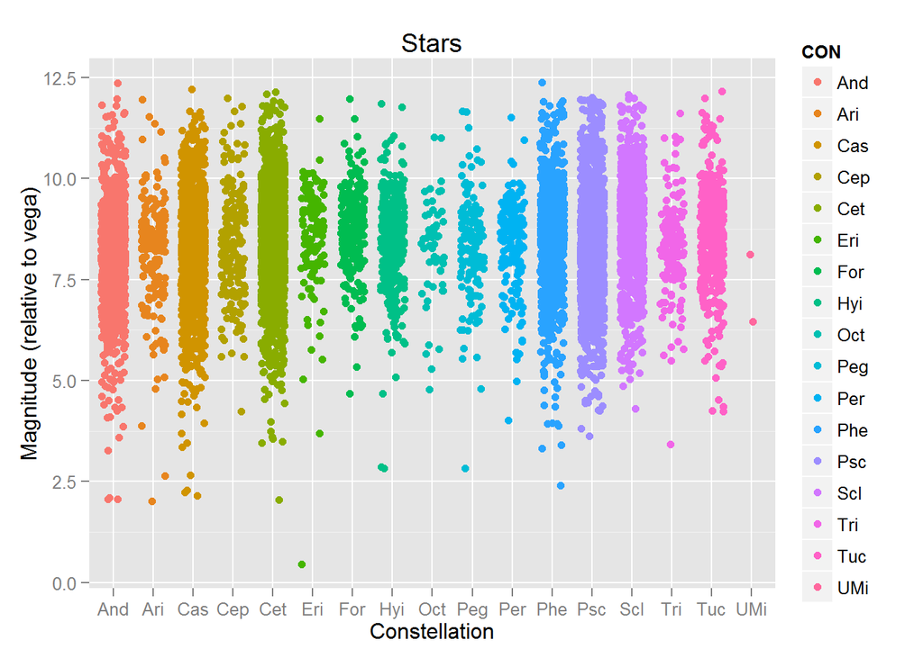

This Visualization shows that the constellations all have a relatively similar distribution of magnitudes around 8.5

```r
source("../02 Data Wrangling/Workflow 2.R", echo = TRUE)
```

```
##
## > require("jsonlite")
##
## > require("RCurl")
##
## > require("ggplot2")
##
## > require("dplyr")
##
## > dfJ <- select(df, ID, DIST, CON, LUM) %>% mutate(lum_percent = cume_dist(LUM)) %>%
## +     filter(lum_percent >= 0.99, CON != "null")
##
## > require(extrafont)
##
## > ggplot() + coord_cartesian() + scale_x_discrete() +
## +     scale_y_continuous() + labs(title = "Stars") + labs(x = "Distance from Earth",
## +     y = .... [TRUNCATED]
```

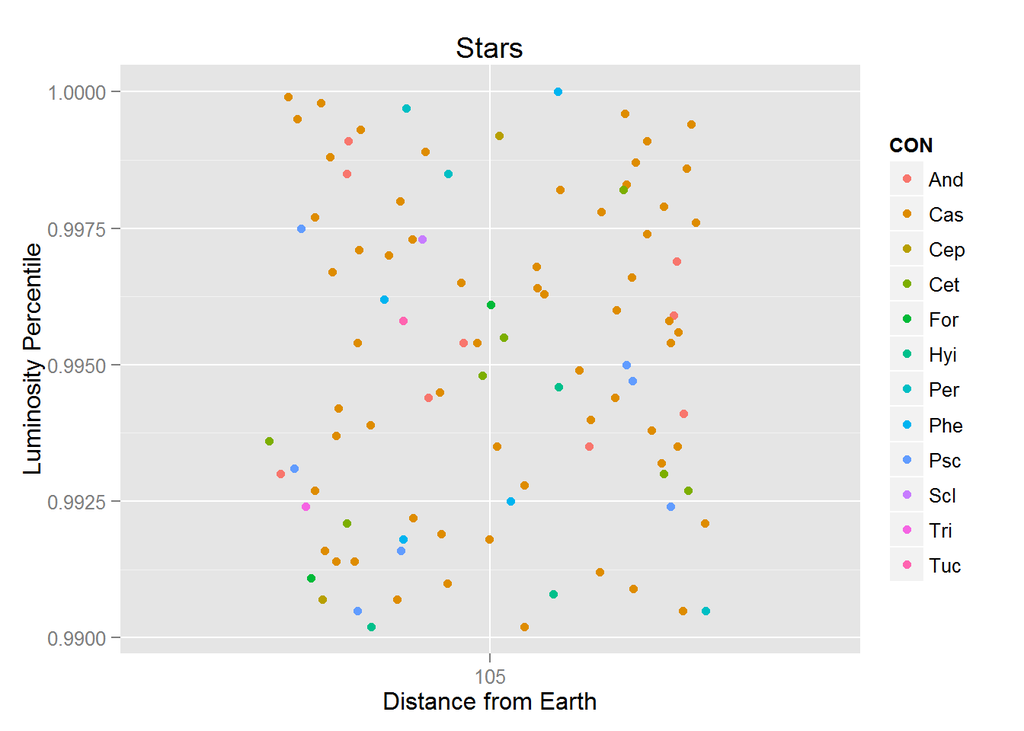

This graph shows that all of the most luminous stars are located relatively equidistant from the Earth. This is an interesting idea, showing that the variability in distance from the Earth is similar for the top 100 stars in the databse.

This visualization shows the stars that have a non-zero radial velocity colored by magnitude As part of my investigation I used the group_by function in my workflow to generate a table that shows the number of stars that each constellation has in this dataset.

```r
source("../02 Data Wrangling/Workflow 4.R", echo = TRUE)
```

```
##
## > require("jsonlite")
##
## > require("RCurl")
##
## > require("ggplot2")
##
## > require("dplyr")
##
## > dfm <- select(df, ID, DIST, CON, ABSMAG, MAG, RV,
## +     LUM, VX, VY, VZ) %>% filter(RV != 0, VX != 0, RV >= -100,
## +     RV <= 100) %>% arrange(CON .... [TRUNCATED]
##
## > dfm2 <- dfm %>% group_by(CON) %>% summarise(n = n()) %>%
## +     arrange(n)
##
## > dfm2
## Source: local data frame [18 x 2]
##
##     CON   n
## 1   UMi   1
## 2  null   2
## 3   Oct   7
## 4   Eri  11
## 5   Ari  30
## 6   Hyi  34
## 7   For  35
## 8   Peg  36
## 9   Cep  37
## 10  Tri  42
## 11  Tuc  43
## 12  Per  47
## 13  Phe 127
## 14  Scl 187
## 15  Psc 275
## 16  Cet 296
## 17  And 308
## 18  Cas 409
##
## > require(extrafont)
##
## > ggplot() + coord_cartesian() + scale_x_continuous() +
## +     scale_y_continuous() + labs(title = "Stars") + labs(x = "Radial Velocity",
## +     y = p .... [TRUNCATED]
```

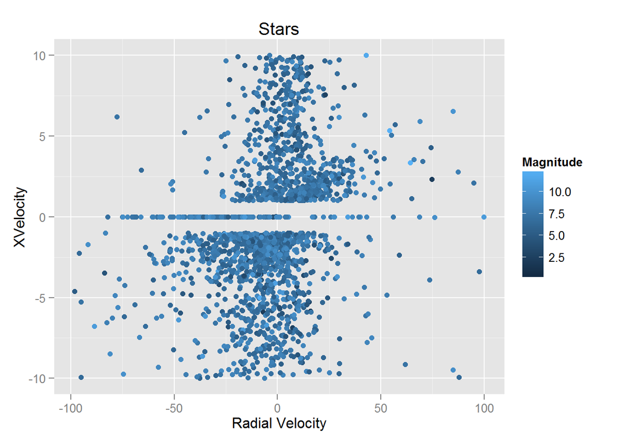